# Formal Groups and Spectra

## Lazard Ring

- What is the Lazard ring?

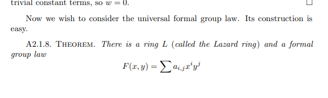

- What does it mean to be a “universal” coefficient ring?

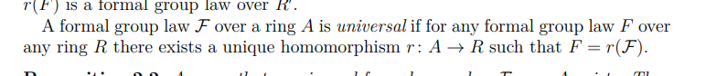

- How exactly is the Lazard ring universal?

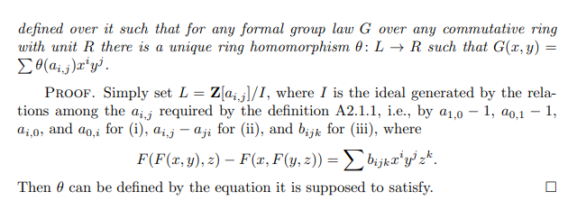

- How are formal groups related to spectra?
- What is MU?
- How are formal groups related to cobordism?

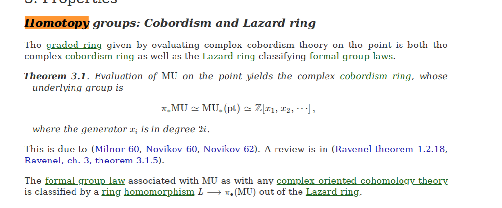

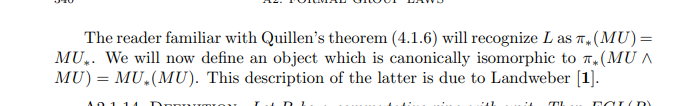

- What is a complex oriented cohomology theory?

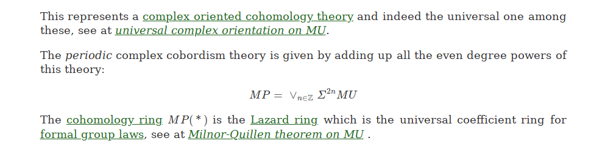

- How is the Lazard ring directly related to cobordism classification?

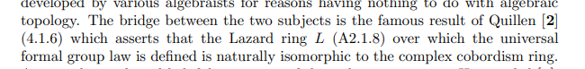

- What is the moduli stack of formal groups?

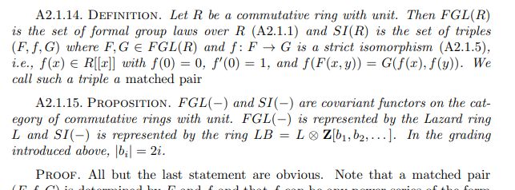

## Stable Homotopy

### tmf

- How is tmf related to modular forms?

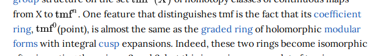

- How is tmf defined in terms of the moduli stack of elliptic curves?

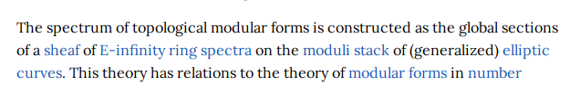

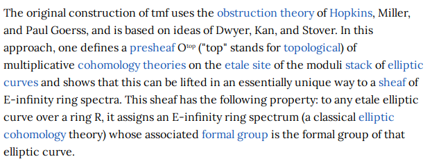

### K-Theories

- How is the algebraic K-theory of a commutative ring defined/constructed in terms of monoidal categories?

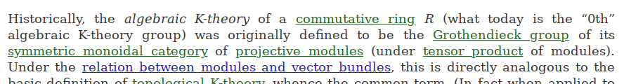

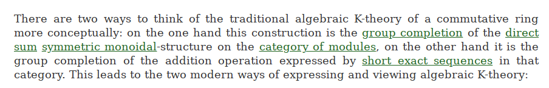